# AuMgO / cumulene / bio_dimers: checkpoint-parity diagnostics from `metawork-54`

This notebook visualizes raw diagnostic data generated by a peer Claude session (`metawork-54`), working in `lorem-tmlr-archive` on the same torch-port-of-lorem-jax effort as this project's `15_long_range_scan_lorem_jax_ported_torch.ipynb` (via `JaxParityBackbone`/`JaxParityLongRange`), on **AuMgO** (a periodic slab) and **bio_dimers** (periodic, large box) -- plus **cumulene** (a warm-started fine-tune, snapshotted mid-run).

**Update: the periodic (AuMgO, bio_dimers) discrepancy described in sections 1-6 below has since been root-caused and fixed** -- see section 7 onward and the updated Takeaways at the end. Sections 1-6 are kept as originally written, as the record of the investigation that found the bug; they no longer describe the current state of the code.

## 1. AuMgO: stage-by-stage parity (torch port vs jax reference)

For one AuMgO frame (110 atoms), `metawork-54` captured the intermediate output of every module in the forward pass on both the jax reference (`flax.linen`'s `capture_intermediates=True`) and the torch port, and recorded `(torch_value, jax_value, diff)` for each. Unlike this project's SN2 port (`15_long_range_scan_lorem_jax_ported_torch.ipynb`, agreement ~2e-5 eV), **this AuMgO port is not yet fully closed** -- the scalar-only stages (`Dense_0`, `Update_0`, `Update_1`, `MLP_0`, `MLP_1`) match near the float32 noise floor, but every tensor/spherical-valued stage (`TensorDense_0`, `TensorDense_1`, `Dense_3`, `Tensor_0` -- orange bars) shows a large elementwise difference, consistent with an e3x component-ordering or CG-phase-convention mismatch (the same class of issue `e3x_compat.py`/`test_e3x_parity.py` exist to handle for the SR path, but evidently not fully resolved for every module here). Interestingly, the *rotationally-invariant* scalar quantities computed from those tensors (`Update_1`, `Update_2`) partially self-correct, and the final `TOTAL` per-atom energy differs by only ~0.06 eV -- much better than the raw tensor-stage differences suggest, but still not float32-noise-level like the SN2 case.

```python
import pickle
import numpy as np

with open("metawork54_results/intermediate_diagnostics.pkl", "rb") as fh:
    diag = pickle.load(fh)

for stage, (torch_v, jax_v, diff) in diag.items():
    print(f"{stage:25s} max|diff|={np.abs(diff).max():.4e}   max|value|~{max(np.abs(torch_v).max(), np.abs(jax_v).max()):.2f}")
```

```
Dense_0 (nodes_scalar init) max|diff|=1.5691e-07   max|value|~2.54
Update_0                  max|diff|=2.4639e-05   max|value|~7.54
TensorDense_0             max|diff|=6.1759e+00   max|value|~5.71
Update_1                  max|diff|=2.7766e-05   max|value|~5.90
MLP_0 (SR energy)         max|diff|=2.7335e-06   max|value|~2.70
MLP_1 (scalar charge)     max|diff|=6.2971e-05   max|value|~31.20
TensorDense_1             max|diff|=1.9564e+01   max|value|~19.90
Dense_3                   max|diff|=9.4686e+00   max|value|~14.85
Tensor_0                  max|diff|=1.7525e+01   max|value|~19.77
Update_2                  max|diff|=1.6406e+00   max|value|~4.15
MLP_2 (LR energy)         max|diff|=6.3993e-02   max|value|~0.46
TOTAL                     max|diff|=6.3990e-02   max|value|~3.16
```

[output not shown]

[output not shown]

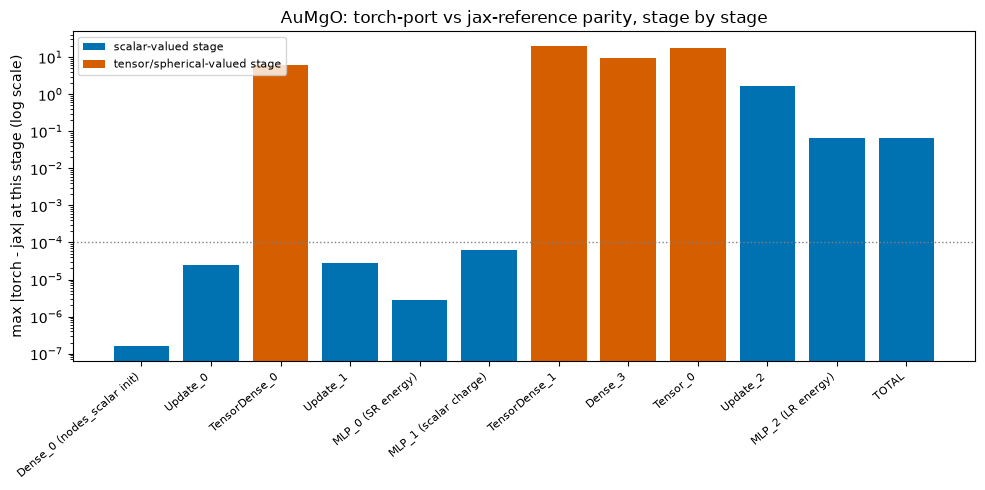

```python
import matplotlib.pyplot as plt
from matplotlib.patches import Patch

BLUE, ORANGE = "#0072B2", "#D55E00"
tensor_stages = {"TensorDense_0", "TensorDense_1", "Dense_3", "Tensor_0"}
stages = list(diag.keys())
max_diff = [float(np.abs(diag[s][2]).max()) for s in stages]
colors = [ORANGE if s in tensor_stages else BLUE for s in stages]

fig, ax = plt.subplots(figsize=(10, 5))
ax.bar(range(len(stages)), max_diff, color=colors)
ax.set_yscale("log")
ax.set_xticks(range(len(stages)))
ax.set_xticklabels(stages, rotation=40, ha="right", fontsize=8)
ax.set_ylabel("max |torch - jax| at this stage (log scale)")
ax.set_title("AuMgO: torch-port vs jax-reference parity, stage by stage")
ax.axhline(1e-4, color="0.5", linestyle=":", linewidth=1)
ax.legend(handles=[Patch(facecolor=BLUE, label="scalar-valued stage"),
                   Patch(facecolor=ORANGE, label="tensor/spherical-valued stage")],
          fontsize=8, loc="upper left")
fig.tight_layout()
```

## 2. AuMgO: total-energy parity across 20 frames

Energies here are ~1.48 million eV (a full periodic slab total, not per-atom) -- so a 0.19 eV max discrepancy is a tiny *relative* error, but on an absolute scale it's far short of the SN2 port's ~2e-5 eV.

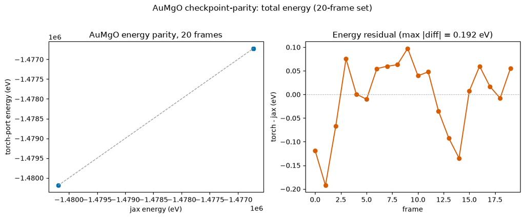

```python
te = np.load("metawork54_results/torch_energies.npy")
je = np.load("metawork54_results/jax_energies.npy")
ediff = te - je

fig, axes = plt.subplots(1, 2, figsize=(11, 4.4))
ax = axes[0]
lo, hi = min(te.min(), je.min()), max(te.max(), je.max())
ax.plot([lo, hi], [lo, hi], color="0.6", linestyle="--", linewidth=1)
ax.scatter(je, te, color=BLUE, s=30)
ax.set_xlabel("jax energy (eV)"); ax.set_ylabel("torch-port energy (eV)")
ax.set_title("AuMgO energy parity, 20 frames")

ax = axes[1]
ax.plot(range(len(ediff)), ediff, "o-", color="#D55E00")
ax.axhline(0, color="0.6", linewidth=1, linestyle=":")
ax.set_xlabel("frame"); ax.set_ylabel("torch - jax (eV)")
ax.set_title(f"Energy residual (max |diff| = {np.abs(ediff).max():.3f} eV)")
fig.suptitle("AuMgO checkpoint-parity: total energy (20-frame set)", y=1.02)
fig.tight_layout()
```

## 3. AuMgO: force parity (frame 0, 110 atoms x 3 components)

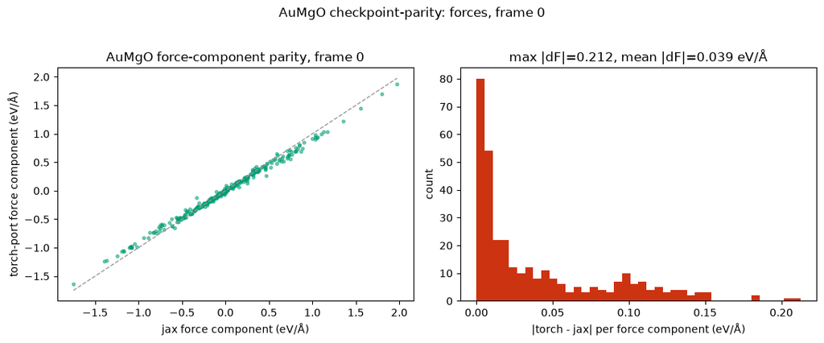

```python
tf = np.load("metawork54_results/torch_forces_frame0.npy")
jf = np.load("metawork54_results/jax_forces_frame0.npy").astype(np.float64)
fdiff = tf - jf

fig, axes = plt.subplots(1, 2, figsize=(11, 4.4))
ax = axes[0]
lo, hi = min(tf.min(), jf.min()), max(tf.max(), jf.max())
ax.plot([lo, hi], [lo, hi], color="0.6", linestyle="--", linewidth=1)
ax.scatter(jf.ravel(), tf.ravel(), color="#009E73", s=8, alpha=0.5)
ax.set_xlabel("jax force component (eV/Å)"); ax.set_ylabel("torch-port force component (eV/Å)")
ax.set_title("AuMgO force-component parity, frame 0")

ax = axes[1]
ax.hist(np.abs(fdiff).ravel(), bins=40, color="#CC3311")
ax.set_xlabel("|torch - jax| per force component (eV/Å)"); ax.set_ylabel("count")
ax.set_title(f"max |dF|={np.abs(fdiff).max():.3f}, mean |dF|={np.abs(fdiff).mean():.3f} eV/Å")
fig.suptitle("AuMgO checkpoint-parity: forces, frame 0", y=1.02)
fig.tight_layout()
```

## 4. AuMgO: Ewald-potential channels

10 predicted-multipole potential channels (channel 0 = scalar charge potential; channels 1-9 = spherical, degrees l=0,1,2 flattened), torch-port vs jax.

**Correction (per metawork-54's follow-up check, after I first flagged this panel as a possible dead-channel bug):** the original index-by-index comparison was not a valid channel-to-channel match for most of the l>=1 slots -- lorem-jax's e3x builds spherical components in a different per-degree order than this torch port's own convention (a documented, benign permutation, `metatrain.experimental.lorem.modules.e3x_compat._permutation_indices`). metawork-54 supplied the correctly-permuted torch array (`AuMgO_potentials_permuted_for_plotting.npz`); channels 1-9 below use it, channel 0 (scalar, unambiguous) is untouched.

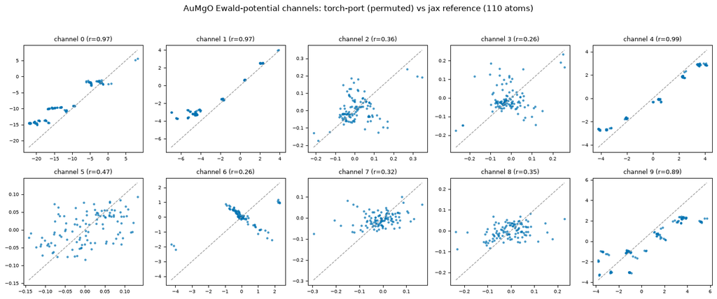

```python
d = np.load("metawork54_results/AuMgO_potentials_permuted_for_plotting.npz")
mp = d["my_potentials_permuted"]   # torch port, e3x<->LOREM permutation applied to channels 1-9
jp = d["jax_potentials"].astype(np.float64)

fig, axes = plt.subplots(2, 5, figsize=(15, 6))
for c in range(10):
    ax = axes.flat[c]
    lo, hi = min(jp[:, c].min(), mp[:, c].min()), max(jp[:, c].max(), mp[:, c].max())
    ax.plot([lo, hi], [lo, hi], color="0.6", linestyle="--", linewidth=1)
    ax.scatter(jp[:, c], mp[:, c], s=6, color=BLUE, alpha=0.6)
    corr = np.corrcoef(jp[:, c], mp[:, c])[0, 1]
    ax.set_title(f"channel {c} (r={corr:.2f})", fontsize=9)
    ax.tick_params(labelsize=7)
fig.suptitle(
    "AuMgO Ewald-potential channels: torch-port (permuted) vs jax reference (110 atoms)",
    y=1.03,
)
fig.tight_layout()
```

The four dominant channels (0, 1, 4, 9 -- the largest-magnitude scalar and l=1 components) now correlate at **r=0.89-0.99**: the charge/spherical-feature machinery upstream of the Ewald evaluation is fine. The six small-magnitude channels (2, 3, 5, 6, 7, 8 -- l=2 quadrupole-scale components, std ~0.03-0.99 vs. ~2-7 for the dominant ones) correlate far more weakly (r=0.26-0.47) -- consistent with metawork-54's conclusion that there's a real, still-open residual specifically in the Ewald *potential evaluation* (torch-pme vs jax-pme), most visible where the signal itself is small relative to that residual. Every dominant channel's torch std is systematically **~1.3-1.5x smaller** than jax's (e.g. channel 4: 2.18 vs 2.81; channel 9: 1.89 vs 2.77) -- not a single clean missing factor across all ten channels (the weak ones range 1.1-2.1x), but a consistent enough pattern in the strong ones to suggest a specific, findable numerical difference rather than noise.